# Investigation of "No Show" Appointments Dataset

*By: Olamilekan Adenusi*

*May 28, 2022*

- Introduction
- Data Wrangling
- Exploratory Data Analysis
- Conclusions

# Introduction

In partial fulfillment of the requirements for passing the ALX-T Udacity Data Analyst course, this project has been undertaken. The aim of this project is to dive into a specific dataset with questions hoping to be answered by the end of the analysis.

Medical appointments are being scheduled everyday but how do we determine those who show up for their appointments? Are there certain factors in this data that determine whether a patient shows up or not? For instance, are males more likely to miss their appointments than females? Does the appointment day have an effect on who shows up or not? Are older patients more committed to their medical schedules than younger ones? Are older patients at more risk of having a specific health problem? Let the data speak for itself!

The dataset used in this analysis contains information about over 100,000 medical appointments in Brazil, focusing on whether patients **showed up or not** for their appointments.

## Packages

The packages used in this analysis include:

1. **pandas** to read in the data/for data manipulation
2. **numpy** for working with arrays
3. **matplotlib** and **seaborn** for data visualization

These packages are now loaded below.

```python
# Render visualizations in the notebook
%matplotlib inline

import pandas as pd
import numpy as np
import matplotlib.pyplot as plt
import seaborn as sns
```

```python
plt.style.use('seaborn')
```

# Data Wrangling

## I. Data Import and Preview

In this section, we will load the data and preview it to get a picture of what we are dealing with. Originally, this dataset can be obtained from [kaggle](https://www.google.com/url?q=https://www.kaggle.com/joniarroba/noshowappointments&sa=D&ust=1532469042118000). In this work, however it was directly downloaded via this [link](https://www.google.com/url?q=https://d17h27t6h515a5.cloudfront.net/topher/2017/October/59dd2e9a_noshowappointments-kagglev2-may-2016/noshowappointments-kagglev2-may-2016.csv&sa=D&ust=1532469042118000). We will first load the data into a dataframe `df` using `pandas`. Then we will display summary about the data.

Although the column names are explanatory, it helps to still provide context. Below is some data description:

- **PatientId** and **AppointmentID** identify the patient and the appointment respectively.
- **ScheduledDay** is the day someone made an appointment while **AppointmentDay** is the day of actual appointment.
- The columns **Scholarship, Hipertension, Alcoholism, Diabetes, and SMS_received** all represent boolean values.
- **No-show** is a categorical column indicating whether a patient showed up (No) or not (Yes). This might be a bit weird to process at first, so in this work, the column shall be renamed to **Show** and its values changed so that Yes indicates a patient showed up while No indicates they didn't.

```python
# Load csv file
df = pd.read_csv('noshowappointments-kagglev2-may-2016.csv')
print('There are {} instances and {} fields in the data'.format(*df.shape))
```

```
There are 110527 instances and 14 fields in the data
```

```python
# Display summary of data
df.info()
```

```
<class 'pandas.core.frame.DataFrame'>
RangeIndex: 110527 entries, 0 to 110526
Data columns (total 14 columns):
 #   Column          Non-Null Count   Dtype
---  ------          --------------   -----
 0   PatientId       110527 non-null  float64
 1   AppointmentID   110527 non-null  int64
 2   Gender          110527 non-null  object
 3   ScheduledDay    110527 non-null  object
 4   AppointmentDay  110527 non-null  object
 5   Age             110527 non-null  int64
 6   Neighbourhood   110527 non-null  object
 7   Scholarship     110527 non-null  int64
 8   Hipertension    110527 non-null  int64
 9   Diabetes        110527 non-null  int64
 10  Alcoholism      110527 non-null  int64
 11  Handcap         110527 non-null  int64
 12  SMS_received    110527 non-null  int64
 13  No-show         110527 non-null  object
dtypes: float64(1), int64(8), object(5)
memory usage: 11.8+ MB
```

- The data consists of different types such as integer, object, and float.
- The "PatientId" and "AppointmentID" columns have incorrectly been treated as float and integers respectively where they ought to be strings.
- The "ScheduledDay" and "AppointmentDay" would be better treated as date objects rather than mere strings.
- "Hipertension" and "Handcap" are incorrectly named

```python
# display first 5 rows
df.head()
```

|  | PatientId | AppointmentID | Gender | ScheduledDay | AppointmentDay | Age | Neighbourhood | Scholarship | Hipertension | Diabetes | Alcoholism | Handcap | SMS_received | No-show |
| --- | --- | --- | --- | --- | --- | --- | --- | --- | --- | --- | --- | --- | --- | --- |
| 0 | 2.987250e+13 | 5642903 | F | 2016-04-29T18:38:08Z | 2016-04-29T00:00:00Z | 62 | JARDIM DA PENHA | 0 | 1 | 0 | 0 | 0 | 0 | No |
| 1 | 5.589978e+14 | 5642503 | M | 2016-04-29T16:08:27Z | 2016-04-29T00:00:00Z | 56 | JARDIM DA PENHA | 0 | 0 | 0 | 0 | 0 | 0 | No |
| 2 | 4.262962e+12 | 5642549 | F | 2016-04-29T16:19:04Z | 2016-04-29T00:00:00Z | 62 | MATA DA PRAIA | 0 | 0 | 0 | 0 | 0 | 0 | No |
| 3 | 8.679512e+11 | 5642828 | F | 2016-04-29T17:29:31Z | 2016-04-29T00:00:00Z | 8 | PONTAL DE CAMBURI | 0 | 0 | 0 | 0 | 0 | 0 | No |
| 4 | 8.841186e+12 | 5642494 | F | 2016-04-29T16:07:23Z | 2016-04-29T00:00:00Z | 56 | JARDIM DA PENHA | 0 | 1 | 1 | 0 | 0 | 0 | No |

```python
# Display summary statistics for numeric columns
df.describe()
```

|  | PatientId | AppointmentID | Age | Scholarship | Hipertension | Diabetes | Alcoholism | Handcap | SMS_received |
| --- | --- | --- | --- | --- | --- | --- | --- | --- | --- |
| count | 1.105270e+05 | 1.105270e+05 | 110527.000000 | 110527.000000 | 110527.000000 | 110527.000000 | 110527.000000 | 110527.000000 | 110527.000000 |
| mean | 1.474963e+14 | 5.675305e+06 | 37.088874 | 0.098266 | 0.197246 | 0.071865 | 0.030400 | 0.022248 | 0.321026 |
| std | 2.560949e+14 | 7.129575e+04 | 23.110205 | 0.297675 | 0.397921 | 0.258265 | 0.171686 | 0.161543 | 0.466873 |
| min | 3.921784e+04 | 5.030230e+06 | -1.000000 | 0.000000 | 0.000000 | 0.000000 | 0.000000 | 0.000000 | 0.000000 |
| 25% | 4.172614e+12 | 5.640286e+06 | 18.000000 | 0.000000 | 0.000000 | 0.000000 | 0.000000 | 0.000000 | 0.000000 |
| 50% | 3.173184e+13 | 5.680573e+06 | 37.000000 | 0.000000 | 0.000000 | 0.000000 | 0.000000 | 0.000000 | 0.000000 |
| 75% | 9.439172e+13 | 5.725524e+06 | 55.000000 | 0.000000 | 0.000000 | 0.000000 | 0.000000 | 0.000000 | 1.000000 |
| max | 9.999816e+14 | 5.790484e+06 | 115.000000 | 1.000000 | 1.000000 | 1.000000 | 1.000000 | 4.000000 | 1.000000 |

### Some Key Observations

- There are no missing values.
- The Age column contains one or more negative values that must be handled appropriately. This will be investigated further in the next section.

## II. Data Cleaning

Some of the operations performed in this section are outlined below:

- To avoid having to look up the column names too often, we shall adopt a consistent column naming convention. I make all column names to be lower case letters.
- Perform the necessary data type casting for the relevant columns: **appointmentid** (int to str), **patientid** (float to str), **scheduledday** (object to datetime), and **appointmentday** (object to datetime). Because the patientid column is float type, it leaves a period that must be replaced by an empty string, e.g 2345678.0 to 2345678
- Rename "hipertension" to "hypertension" and "handcap" to "handicap"
- Also rename "no-show" to "show" and convert the values to 1s and 0s so that 1 indicates Yes while 0 indicates No (a missed appointment)

```python
# Rename columns to all lower case
df.columns = df.columns.str.lower()
```

```python
# Change data types
df['patientid'] = df['patientid'].astype('str').str.replace('.0', '', regex=False)
df['appointmentid'] = df['appointmentid'].astype('str')
df['scheduledday'] = pd.to_datetime(df['scheduledday'])
df['appointmentday'] = pd.to_datetime(df['appointmentday'])
```

```python
# column renaming
df.rename(columns={'hipertension': 'hypertension', 'handcap':'handicap'}, inplace=True)
```

```python
# column renaming
df.rename(columns={'no-show':'show'}, inplace=True)

# 1 --> patient showed up for the appointment, 0 --> patient missed the appointment
df['show'] = df['show'].apply(lambda x: 1 if x=='No' else 0)
```

### Examining patients with ages less than or equal to zero

```python
# Output data for patients with negative or zero age
df.query('age <= 0').head()
```

|  | patientid | appointmentid | gender | scheduledday | appointmentday | age | neighbourhood | scholarship | hypertension | diabetes | alcoholism | handicap | sms_received | show |
| --- | --- | --- | --- | --- | --- | --- | --- | --- | --- | --- | --- | --- | --- | --- |
| 59 | 71844284745331 | 5638545 | F | 2016-04-29 08:08:43+00:00 | 2016-04-29 00:00:00+00:00 | 0 | CONQUISTA | 0 | 0 | 0 | 0 | 0 | 0 | 1 |
| 63 | 236623344873175 | 5628286 | M | 2016-04-27 10:46:12+00:00 | 2016-04-29 00:00:00+00:00 | 0 | SÃO BENEDITO | 0 | 0 | 0 | 0 | 0 | 0 | 1 |
| 64 | 188517384712787 | 5616082 | M | 2016-04-25 13:28:21+00:00 | 2016-04-29 00:00:00+00:00 | 0 | ILHA DAS CAIEIRAS | 0 | 0 | 0 | 0 | 0 | 1 | 1 |
| 65 | 271881817799985 | 5628321 | M | 2016-04-27 10:48:50+00:00 | 2016-04-29 00:00:00+00:00 | 0 | CONQUISTA | 0 | 0 | 0 | 0 | 0 | 0 | 1 |
| 67 | 86471282513499 | 5639264 | F | 2016-04-29 08:53:02+00:00 | 2016-04-29 00:00:00+00:00 | 0 | NOVA PALESTINA | 0 | 0 | 0 | 0 | 0 | 0 | 1 |

```python
# Get number of patients with ages <= 0
print('{} patients'.format(df.query('age <= 0').shape[0]))
```

```
3540 patients
```

```python
df.query('age <= 0').age.value_counts()
```

```
 0    3539
-1       1
Name: age, dtype: int64
```

- There are 3540 patients with ages <= 0. Only **1** patient had a negative age. This is most likely an error in data collection. This data will be dropped.
- Patients with zero age are most likely babies below 1 year. Let's check whether babies were diagnosed with alcoholism, hypertension, and/or diabetes. This would be weird since they are only babies. If there are none, then it is safe to conclude that they are indeed babies.

```python
# First drop the instance with a negative age
df.drop(df.query('age < 0').index, axis='rows', inplace=True)
```

Next extract those patients with zero age and perform necessary operations on the relevant columns.

```python
babies = df.query('age == 0')
```

```python
# first sum hypertension, alcoholism, and diabetes
babies[['hypertension', 'alcoholism', 'diabetes']].sum(axis=1)
```

```
59        0
63        0
64        0
65        0
67        0
         ..
110345    0
110346    0
110454    0
110460    0
110507    0
Length: 3539, dtype: int64
```

```python
# then sum all the rows
babies[['hypertension', 'alcoholism', 'diabetes']].sum(axis=1).sum(axis=0)
```

```
0
```

Since there is no patient (with age = 0) that was diagnosed with alcoholism, diabetes, or hypertension, it is safe to say that patients with zero ages were all babies below 1 year.

### Checking for Duplicate values

The next cell reveals that no two rows are exactly the same.

```python
# Check for duplicate values
sum(df.duplicated())
```

```
0
```

But what about patient ids that are duplicated? In the dataframe below, the first 2 rows, for example, represent the same patient who had different medical appointments at Maria Ortiz and on different days.

```python
df[ df.duplicated(subset='patientid', keep=False)].sort_values(by='patientid').head(2)
```

|  | patientid | appointmentid | gender | scheduledday | appointmentday | age | neighbourhood | scholarship | hypertension | diabetes | alcoholism | handicap | sms_received | show |
| --- | --- | --- | --- | --- | --- | --- | --- | --- | --- | --- | --- | --- | --- | --- |
| 51059 | 111124532532143 | 5531224 | M | 2016-03-31 09:17:26+00:00 | 2016-05-03 00:00:00+00:00 | 9 | MARIA ORTIZ | 0 | 0 | 0 | 0 | 0 | 1 | 1 |
| 95359 | 111124532532143 | 5624030 | M | 2016-04-26 15:05:58+00:00 | 2016-06-01 00:00:00+00:00 | 9 | MARIA ORTIZ | 0 | 0 | 0 | 0 | 0 | 1 | 0 |

I would not be dropping these rows right away as they might be useful later when exploring the research questions.

# Exploratory Data Analysis

Let's first plot a histogram for all numeric columns in the data to get an idea of their distribution.

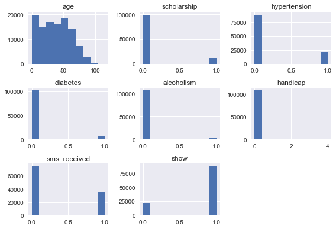

```python
plt.figure(figsize=(14, 14))

df.drop(['scheduledday', 'appointmentday'], axis='columns').hist()
plt.tight_layout();
```

## Research Question I

> How does the proportion of those who showed up for their appointments compare with those who did not?

To answer this we need to make use of the **show** column and examine the number of patients associated with both outcomes.

```python
# Get number of patients for each unique value
df['show'].value_counts()
```

```
1    88207
0    22319
Name: show, dtype: int64
```

We can also visualize this with the aid of a pie chart that displays the proportion of patients.

```python
labels = ['Showed up', 'Didn\'t show up']
```

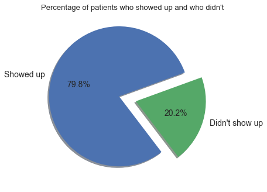

```python
plt.pie(df.show.value_counts(),
        labels=labels,
        explode=(0.2, 0.05),
        startangle=20,
        shadow=True,
        autopct='%.1f%%',
        textprops={'fontsize': 14})

plt.title('Percentage of patients who showed up and who didn\'t', fontsize=13);
```

- Thus, about **80%** of patients showed up for their appointments. Keep in mind that this includes patients who had more than one appointment. What if we were to narrow this down to patients that appear only once to be scheduled for an appointment? Would there be any change?

To do this, we will first drop the data for every patient that had more than one appointment. This is done using pandas' `drop_duplicates` method. We will not be keeping any of the duplicates. For instance, in the dataframe below we will drop the two rows relating to the patient with id 111124532532143.

```python
df[ df.duplicated(subset='patientid', keep=False)].sort_values(by='patientid').head()
```

|  | patientid | appointmentid | gender | scheduledday | appointmentday | age | neighbourhood | scholarship | hypertension | diabetes | alcoholism | handicap | sms_received | show |
| --- | --- | --- | --- | --- | --- | --- | --- | --- | --- | --- | --- | --- | --- | --- |
| 51059 | 111124532532143 | 5531224 | M | 2016-03-31 09:17:26+00:00 | 2016-05-03 00:00:00+00:00 | 9 | MARIA ORTIZ | 0 | 0 | 0 | 0 | 0 | 1 | 1 |
| 95359 | 111124532532143 | 5624030 | M | 2016-04-26 15:05:58+00:00 | 2016-06-01 00:00:00+00:00 | 9 | MARIA ORTIZ | 0 | 0 | 0 | 0 | 0 | 1 | 0 |
| 17494 | 1111633122891 | 5713029 | M | 2016-05-18 09:37:39+00:00 | 2016-05-18 00:00:00+00:00 | 2 | SÃO JOSÉ | 0 | 0 | 0 | 0 | 0 | 0 | 1 |
| 28351 | 1111633122891 | 5674433 | M | 2016-05-09 11:03:50+00:00 | 2016-05-09 00:00:00+00:00 | 2 | SÃO JOSÉ | 0 | 0 | 0 | 0 | 0 | 0 | 1 |
| 34823 | 1111633122891 | 5684529 | M | 2016-05-11 08:45:03+00:00 | 2016-05-11 00:00:00+00:00 | 2 | SÃO JOSÉ | 0 | 0 | 0 | 0 | 0 | 0 | 1 |

```python
df_unique_patients = df.drop_duplicates(subset='patientid', keep=False)
```

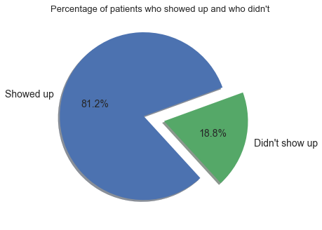

```python
plt.pie(df_unique_patients.show.value_counts(),
        labels=labels,
        explode=(0.2, 0.05),
        startangle=20,
        shadow=True,
        autopct='%.1f%%',
        textprops={'fontsize': 14})

plt.title('Percentage of patients who showed up and who didn\'t', fontsize=13);
```

- Again, just about **81%** of these patients show up for their medical appointments. This is not very different from the previous value.

## Research Question II

> Are Females more committed to their medical appointment than males?

To explore this, let's make a countplot of the number of patients by gender.

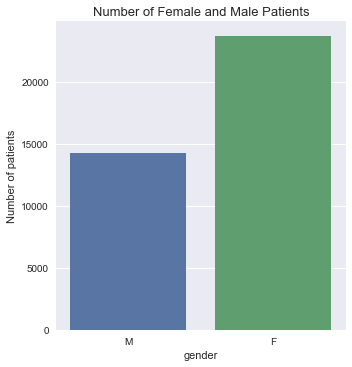

```python
sns.catplot(x='gender', kind='count', data=df_unique_patients,  order=['M', 'F'])

# Set ylabel and title for plot
plt.ylabel('Number of patients')
plt.title('Number of Female and Male Patients', fontsize=13);
```

The above chart reveals that there are more female patients than male patients. But this does not prove that females are more committed. At best, it only tells us more females were scheduled for appointment than males. In the next chart we shall examine the proportion of females who showed up and compare this with the proportion of males who showed up to see if there is a difference.

By grouping by the gender, the distribution of patients across **show** can be determined.

```python
df.groupby(by='gender')['show'].value_counts()
```

```
gender  show
F       1       57245
        0       14594
M       1       30962
        0        7725
Name: show, dtype: int64
```

We however want the the values 0 and 1 to be in separate columns. To do this, the `unstack` method is used. Then a row operation is performed to convert the values to proportions using `apply`.

```python
df.groupby(by='gender')['show'].value_counts().unstack()
```

| show gender | 0 | 1 |
| --- | --- | --- |
| F | 14594 | 57245 |
| M | 7725 | 30962 |

```python
round(df.groupby(by='gender')['show'].value_counts().unstack().apply(lambda row: row/row.sum(), axis=1), 3)*100
```

| show gender | 0 | 1 |
| --- | --- | --- |
| F | 20.3 | 79.7 |
| M | 20.0 | 80.0 |

```python
# Group the data by gender, unstack the MultiIndex, and apply a row operation
show_by_gender = (df.groupby(by='gender')['show'].value_counts()
                    .unstack()
                    .apply(lambda row: row/row.sum(), axis=1))
```

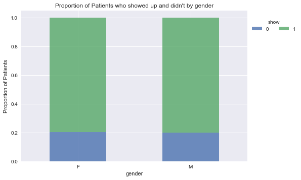

```python
# Plot the bar chart and add a y-axis label
show_by_gender.plot(kind='bar', stacked=True, rot=False, alpha=0.8)
plt.ylabel('Proportion of Patients')
plt.title('Proportion of Patients who showed up and didn\'t by gender')

# Adjust the legend
plt.legend(bbox_to_anchor=(1., 0.9), loc='center left', title='show', ncol=2);
```

The chart above shows that although there are more female than there are male patients, the proportion of females (**79.7%**) and males(**80%**) who showed up are very similar. Thus, it is safe to say that a patient's gender contributes very little to whether they will show up or not.

## Research Question III

> Are patients more likely to miss their appointments if their appointment dates are far?

Consider two patients, A and B. A's appointment day is in two days time, and B's appointment day is in 2 weeks time. Is B less likely to show up for their appointment given that their appointment day is farther?

Relevant columns, namely, `scheduledday` and `appointmentday` have been parsed as datetime objects to aid my analysis. The difference between these dates is computed and stored in the `days_away` column. But before proceeding, let's examine the two columns we'll be using further. At surface level, it seems the `scheduledday` column has time component while the `appointmentday` column does not.

```python
df[['scheduledday', 'appointmentday']].describe(datetime_is_numeric=True)
```

|  | scheduledday | appointmentday |
| --- | --- | --- |
| count | 110526 | 110526 |
| mean | 2016-05-09 07:48:53.920779008+00:00 | 2016-05-19 00:57:35.968731392+00:00 |
| min | 2015-11-10 07:13:56+00:00 | 2016-04-29 00:00:00+00:00 |
| 25% | 2016-04-29 10:27:01+00:00 | 2016-05-09 00:00:00+00:00 |
| 50% | 2016-05-10 12:13:10.500000+00:00 | 2016-05-18 00:00:00+00:00 |
| 75% | 2016-05-20 11:18:30.249999872+00:00 | 2016-05-31 00:00:00+00:00 |
| max | 2016-06-08 20:07:23+00:00 | 2016-06-08 00:00:00+00:00 |

The output in the next cell is 0 which indicates the `appointmentday` column does not have time components. This must mean that the hospitals take only the day of appointment into account, and disregard the time.

```python
sum(df['appointmentday'].dt.hour)
```

```
0
```

Likewise, there is no schedule day that has a zero time component which means the hospital records not just the day, but also the time which a schedule was made.

```python
df[ (df['scheduledday'].dt.hour == 0) & (df['scheduledday'].dt.minute ==0)]
```

|  | patientid | appointmentid | gender | scheduledday | appointmentday | age | neighbourhood | scholarship | hypertension | diabetes | alcoholism | handicap | sms_received | show |
| --- | --- | --- | --- | --- | --- | --- | --- | --- | --- | --- | --- | --- | --- | --- |

Before we proceed we will need to `normalize` all schedule dates to midnight so that the time components are zeroed out just like `appointmentday`

```python
# zero the time components in the scheduledday column
df['scheduledday'] = df['scheduledday'].dt.normalize()
```

```python
# Then determine the number of days between appointment day and the schedule day
df['days_away'] = (df['appointmentday'] - df['scheduledday']).dt.days
```

```python
# Compute summary statistics on the new column
df['days_away'].describe()
```

```
count    110526.000000
mean         10.183794
std          15.255034
min          -6.000000
25%           0.000000
50%           4.000000
75%          15.000000
max         179.000000
Name: days_away, dtype: float64
```

The cell above reveals some of the days are negative, which is unexpected. Digging further, we check the number of occurrences of these instances. Output from the following cell shows that **4** patients had appointment a day before they made a schedule, while **1** patient had appointment 6 days before they were scheduled. I will be dropping these rows since there are only 5 occurrences.

**Note** that it is possible the appointment day was mistaken for the scheduled day in these cases. However, one can't be too sure.

```python
df.query('days_away < 0').days_away.value_counts()
```

```
-1    4
-6    1
Name: days_away, dtype: int64
```

```python
# Filter for negative days
df.query('days_away < 0').head()
```

|  | patientid | appointmentid | gender | scheduledday | appointmentday | age | neighbourhood | scholarship | hypertension | diabetes | alcoholism | handicap | sms_received | show | days_away |
| --- | --- | --- | --- | --- | --- | --- | --- | --- | --- | --- | --- | --- | --- | --- | --- |
| 27033 | 7839272661752 | 5679978 | M | 2016-05-10 00:00:00+00:00 | 2016-05-09 00:00:00+00:00 | 38 | RESISTÊNCIA | 0 | 0 | 0 | 0 | 1 | 0 | 0 | -1 |
| 55226 | 7896293967868 | 5715660 | F | 2016-05-18 00:00:00+00:00 | 2016-05-17 00:00:00+00:00 | 19 | SANTO ANTÔNIO | 0 | 0 | 0 | 0 | 1 | 0 | 0 | -1 |
| 64175 | 24252258389979 | 5664962 | F | 2016-05-05 00:00:00+00:00 | 2016-05-04 00:00:00+00:00 | 22 | CONSOLAÇÃO | 0 | 0 | 0 | 0 | 0 | 0 | 0 | -1 |
| 71533 | 998231581612122 | 5686628 | F | 2016-05-11 00:00:00+00:00 | 2016-05-05 00:00:00+00:00 | 81 | SANTO ANTÔNIO | 0 | 0 | 0 | 0 | 0 | 0 | 0 | -6 |
| 72362 | 3787481966821 | 5655637 | M | 2016-05-04 00:00:00+00:00 | 2016-05-03 00:00:00+00:00 | 7 | TABUAZEIRO | 0 | 0 | 0 | 0 | 0 | 0 | 0 | -1 |

```python
# Drop instances with negative days
df.drop( df.query('days_away < 0').index, axis='rows', inplace=True)
```

Make a boxplot to show how the **days_away** is distributed based on the outcome of the appointment.

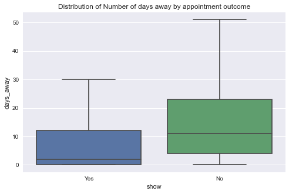

```python
fig, ax = plt.subplots(figsize=(8, 5)) #create a figure and axis object

# make a boxplot with some customizations. Ignore outliers by setting sym to an empty string
sns.boxplot(x='show',
            y='days_away',
            sym='',
            data=df,
            ax=ax,
            order=[1, 0]);

ax.set_xticklabels(['Yes', 'No']) #Set tick labels for the x-axis
plt.title('Distribution of Number of days away by appointment outcome');
```

```python
df.groupby(by='show')['days_away'].median()
```

```
show
0    11.0
1     2.0
Name: days_away, dtype: float64
```

The plot clearly shows us that the median `days_away` for the patients who showed up for their appointments is much smaller than that for those who missed their appointments. In other words, 50% of those who showed up had appointment within at most 2 days of making a schedule, while 50% of those who did not show up had appointment within at most 11 days.

An empirical cumulative distribution plot (ecdf) might help us visualize this even much better. A function `plot_ecdf` is created below for reuse.

```python
def plot_ecdf(series, label=None, color='blue'):
    """
    Plot ecdf of a distribution
    ---------------------------
    Args:
        series: a pandas series or a 1D array
    """

    x = np.sort(series)
    y = np.arange(1, len(x)+1) / len(x)

    plt.plot(x, y, marker='.', linestyle='none', markersize=2, label=label, color=color)

    # set plot title
    plt.title('ECDF plot for {}'.format(series.name))
```

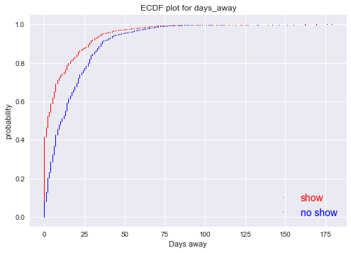

```python
# plot ecdf for patients who showed up
plot_ecdf( df.query('show == 1')['days_away'], label='show', color='red')

# plot ecdf for patients who didn't show up
plot_ecdf(df.query('show == 0')['days_away'], label='no show', color='blue')

plt.xlabel('Days away')
plt.ylabel('probability')
plt.legend(prop={'size':14}, labelcolor=['red', 'blue'])
```

- The blue points are shifted to the right more than the red points, which indicates those who did not show up tend to have farther appointment dates than those who showed up.

## Research Question IV

> Does Age affect show up?

Let's first get a feel for how the patients' ages are distributed using a histogram. Bins are created for every 10-year range.

```python
bins = np.arange(0, 120, 10)
```

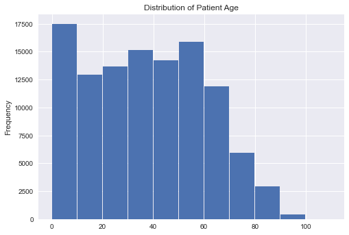

```python
df.age.plot(kind='hist', bins=bins, rwidth=0.96,  xlabel='Age', ylabel='Frequency', title='Distribution of Patient Age');
```

Let us now create age ranges and labels that we can work with.

```python
bins = [-1, 12, 17, 24, 34, 44, 54, 64, 120]
labels = ['<=12', '13-17', '18-24', '25-34', '35-44', '45-54', '55-64', '>=65']
```

Using `pd.cut` allows us to separate the age column into age categories defined by the bins.

```python
df['age_range'] = pd.cut(df.age, bins=bins, labels=labels)
```

```python
df[['age', 'age_range']].head()
```

|  | age | age_range |
| --- | --- | --- |
| 0 | 62 | 55-64 |
| 1 | 56 | 55-64 |
| 2 | 62 | 55-64 |
| 3 | 8 | <=12 |
| 4 | 56 | 55-64 |

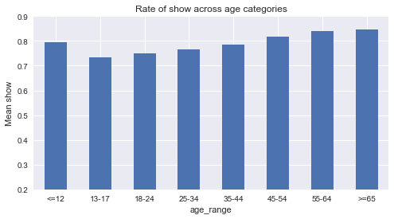

```python
# set figure size
plt.figure(figsize=(8, 4))

# customize bar chart
df.groupby(by='age_range')['show'].mean().plot(kind='bar',
                                               ylabel='Mean show',
                                               title='Rate of show across age categories',
                                               rot=False,
                                               ylim=(0.2, 0.9));
```

Older patients within the age range 45 and above seem to be most committed to their medical appointments. Patients below age 13 are also more committed than those between 13-17 and 18-24.

```python
df.pivot_table(index='gender', columns='age_range', values='show')
```

| age_range gender | <=12 | 13-17 | 18-24 | 25-34 | 35-44 | 45-54 | 55-64 | >=65 |
| --- | --- | --- | --- | --- | --- | --- | --- | --- |
| F | 0.795450 | 0.738906 | 0.750379 | 0.765978 | 0.783829 | 0.816142 | 0.834969 | 0.843872 |
| M | 0.795151 | 0.725172 | 0.750667 | 0.769889 | 0.788522 | 0.818481 | 0.849800 | 0.847367 |

## Research question V

> Does hypertension seem to be more common among older patients?

To explore this we create a new dataframe that holds record of only one appointment for every unique patient. The number of unique hypertensive patients is preserved.

```python
hyp = df.drop_duplicates(subset='patientid').query('hypertension == 1')
```

The mean age of hypertensive patients is 61 years.

```python
hyp.age.mean()
```

```
61.1264499264826
```

Majority of those with hypertension are within the age range of 50-70 years as shown in the histogram below.

```python
bins = np.arange(0, 120, 10)
```

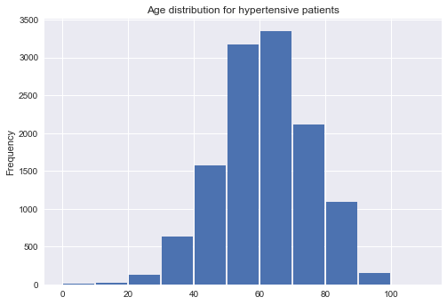

```python
hyp.age.plot(kind='hist',
             rwidth=0.97,
             bins=bins,
             xlabel='Age',
             ylabel='Frequency',
             title='Age distribution for hypertensive patients');
```

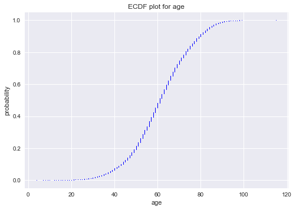

```python
# plot ecdf for age of hypertensive patients
plot_ecdf(hyp.age)

plt.xlabel('age')
plt.ylabel('probability');
```

- The ages are almost normally distributed, but not quite.
- The mean age of hypertensive patients is 61.

## Research question VI

> Are older patients more at risk of being hypertensive and diabetic at the same time?

Create a new dataframe for patients with hypertension and diabetes. Then obtain the normalized respective counts for each age range.

```python
hyp_diab = hyp.query('diabetes == 1').age_range.value_counts(normalize=True)
```

```python
hyp_diab
```

```
>=65     0.476696
55-64    0.304493
45-54    0.154340
35-44    0.052749
25-34    0.009768
18-24    0.001395
<=12     0.000279
13-17    0.000279
Name: age_range, dtype: float64
```

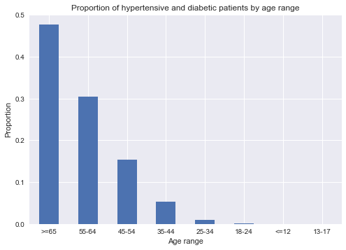

```python
hyp_diab.plot(kind='bar', rot=False,
              xlabel='Age range', ylabel='Proportion',
              title='Proportion of hypertensive and diabetic patients by age range');
```

- Out of all patients with hypertension and diabetes, *48%* of them are at least 65 years of age, *30%* of them are between 55 and 64 years of age, and *15%* are between 45 and 54 years of age. The visualization shows a continuous decrease with decreasing age.

## Limitations

- The reason for scheduling an appointment was not provided, thus making it hard to provide more context into what makes some patients miss their appointments.

## References

- [Medical Appointments No Show](https://www.kaggle.com/datasets/joniarroba/noshowappointments) - data source